# STT 301: More graphics with ggplot2

Rellika Kisyula

10/8/2018

# Introduction

**Learning objectives:**

1. ggplot function
2. geom_bar
3. geom_histogram
4. geom_boxplot
5. geom_raster
6. geom_density The package ggplot2 has many options and capabilities so you will probably find the following ggplot2 help resources useful:
- http://docs.ggplot2.org/current/
- the graphics portion of the R cookbook site at http://www.cookbook-r.com/Graphs/
- http://zevross.com/blog/2014/08/04/beautiful-plotting-in-r-a-ggplot2-cheatsheet-3/
- RStudio “Data Visualization with ggplot2” cheatsheet
- Google

# Part 1

## Bar plots - Diamonds data

The ggplot2 package comes with a data set called diamonds. Let’s look at it below. To obtain further details type ?diamonds in your console window.

```r
library(ggplot2)
str(diamonds)
```

```
## Classes 'tbl_df', 'tbl' and 'data.frame':    53940 obs. of  10 variables:
##  $ carat  : num  0.23 0.21 0.23 0.29 0.31 0.24 0.24 0.26 0.22 0.23 ...
##  $ cut    : Ord.factor w/ 5 levels "Fair"<"Good"<..: 5 4 2 4 2 3 3 3 1 3 ...
##  $ color  : Ord.factor w/ 7 levels "D"<"E"<"F"<"G"<..: 2 2 2 6 7 7 6 5 2 5 ...
##  $ clarity: Ord.factor w/ 8 levels "I1"<"SI2"<"SI1"<..: 2 3 5 4 2 6 7 3 4 5 ...
##  $ depth  : num  61.5 59.8 56.9 62.4 63.3 62.8 62.3 61.9 65.1 59.4 ...
##  $ table  : num  55 61 65 58 58 57 57 55 61 61 ...
##  $ price  : int  326 326 327 334 335 336 336 337 337 338 ...
##  $ x      : num  3.95 3.89 4.05 4.2 4.34 3.94 3.95 4.07 3.87 4 ...
##  $ y      : num  3.98 3.84 4.07 4.23 4.35 3.96 3.98 4.11 3.78 4.05 ...
##  $ z      : num  2.43 2.31 2.31 2.63 2.75 2.48 2.47 2.53 2.49 2.39 ...
```

Last time you created scatter plots such as the one below by making use of `geom_point`.

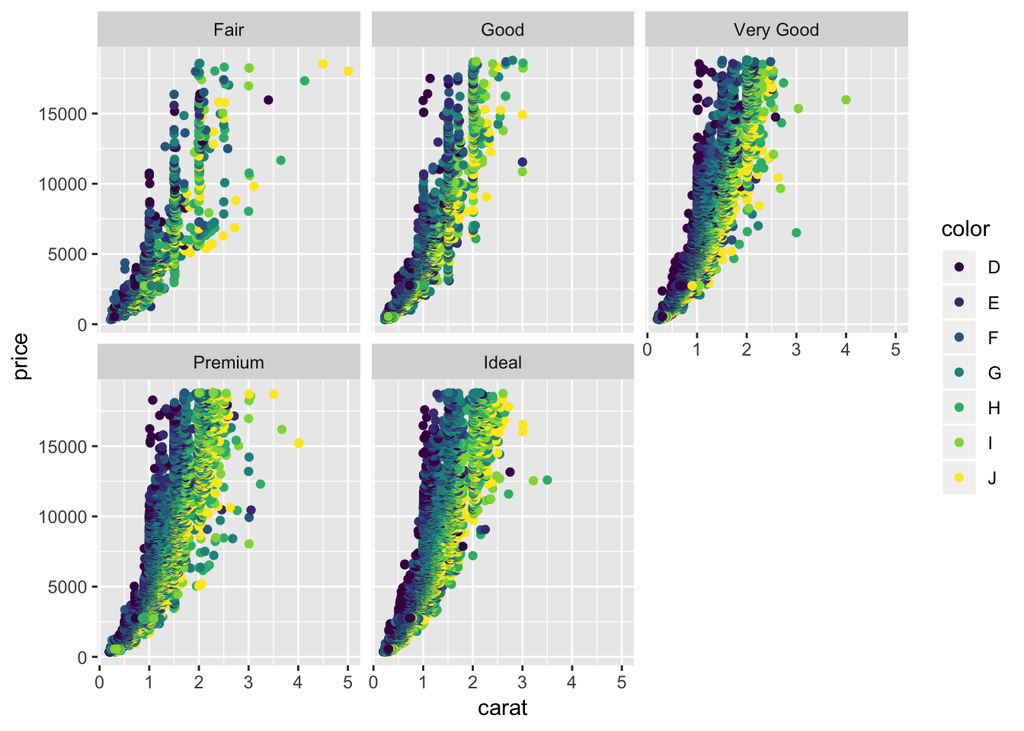

```r
diamond.plot <- ggplot(data=diamonds, aes(x=carat, y=price, colour = color))
diamond.plot + geom_point() + facet_wrap(~cut)
```

Use `geom_bar` to create the bar plots you see below. **Plot a**

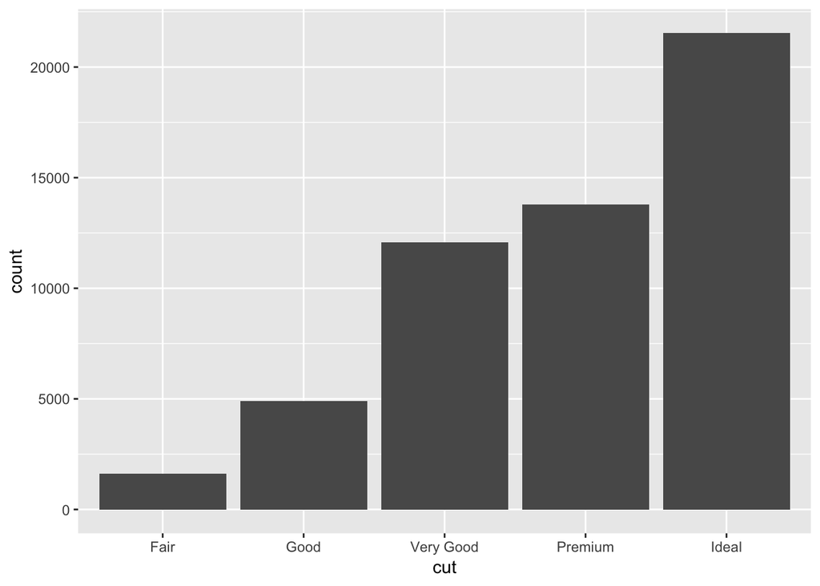

```r
ggplot(diamonds, aes(x = cut)) + geom_bar()
```

**Plot b**

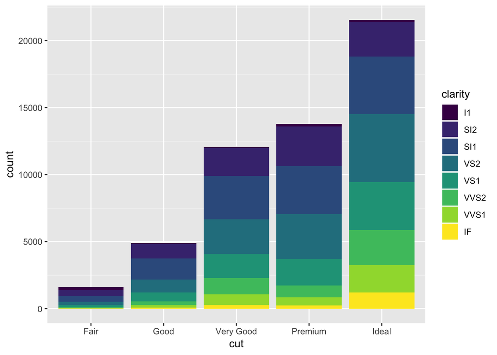

```r
ggplot(diamonds, aes(x = cut, fill = clarity)) + geom_bar()
```

**Plot c**

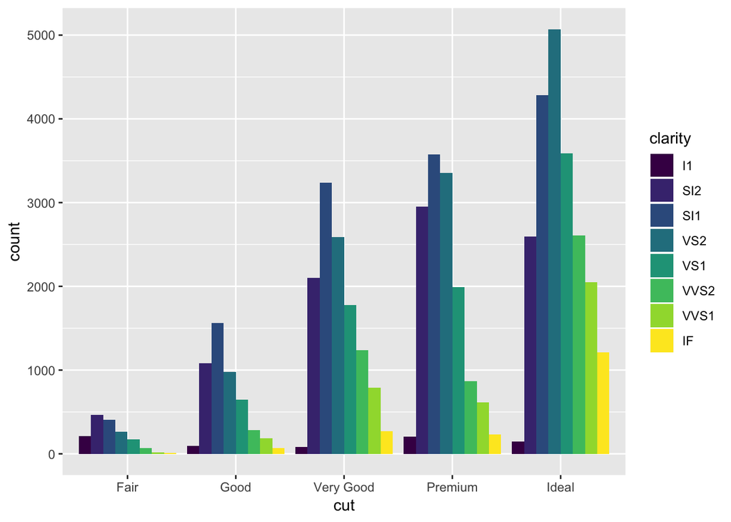

```r
ggplot(diamonds, aes(x = cut, fill = clarity)) +
  geom_bar(position = "dodge")
```

# Part 2

## Histograms - Diamonds data

Use `geom_histogram` to create the histograms you see below.

**Plot a**

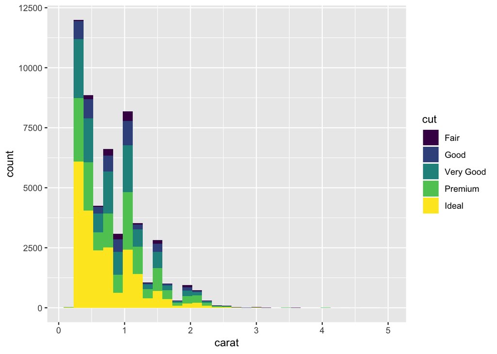

```r
ggplot(diamonds, aes(x = carat, fill = cut)) +
geom_histogram(binwidth = 0.15 )
```

**Plot b** Details:

- binwidth used: 1000
- colors used: “lightblue”, “darkgreen”, “darkorange”, “darkred”
- red line represents the mean price
- orange line represents the median price
- create vertical lines with `geom_vline`

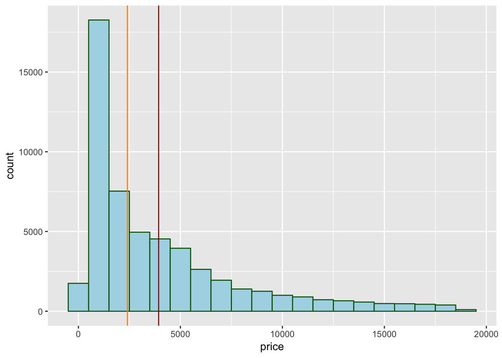

```r
ggplot(diamonds, aes(x = price)) +
  geom_histogram(binwidth = 1000, fill = "lightblue", color ="darkgreen" ) +
  geom_vline(aes(xintercept = mean(price)), color="darkred") +
  geom_vline(aes(xintercept = median(price)), color="darkorange")
```

# Part 3

## Box plots - Diamonds data

Use `geom_boxplot` to create box plots for the plots you see below.

**Plot a** Details:

- colors used: “darkgrey”, “purple”
- use `x = reorder(cut, price, FUN = median)` to arrange box plots by median value
- use `coord_fli`p for horizontal box plots

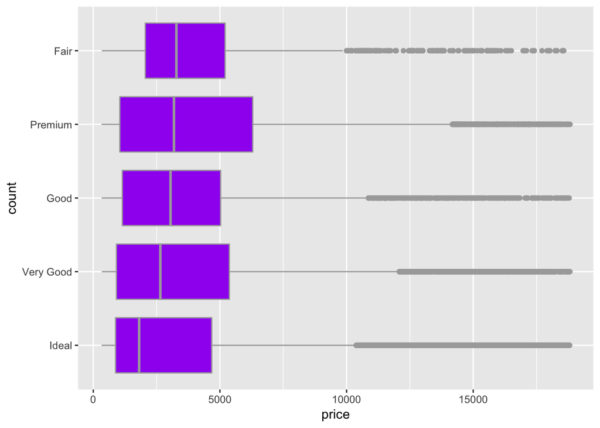

```r
ggplot(data = diamonds,
    aes(x = reorder(cut, price, FUN = median), y = price)) +
  geom_boxplot(color = "darkgrey", fill = "purple") +
  coord_flip() +
  labs(x = "count", y="price")
```

Plot b Details:

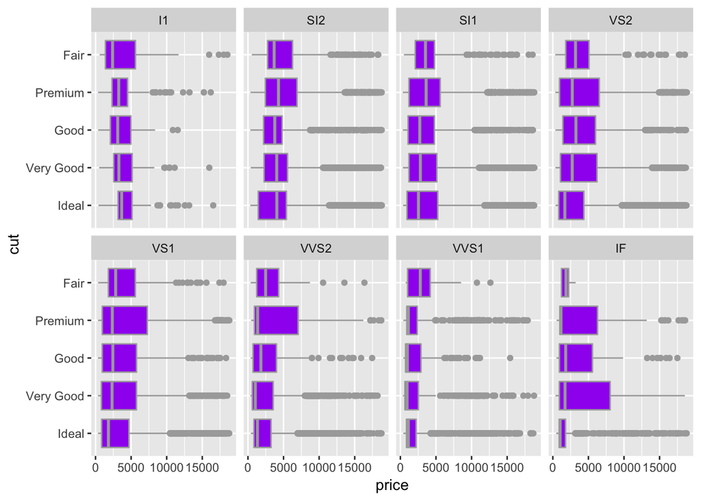

```r
ggplot(data = diamonds,
    aes(x = reorder(cut, price, FUN = median), y = price)) +
  geom_boxplot(color = "darkgrey", fill = "purple") +
  coord_flip() +
  labs(x = "cut", y="price") +
  facet_wrap(~factor(clarity), nrow = 2)
```

# Part 4

## Heat maps - Diamonds data

**Plot a** Use `geom_raster` to create the heat maps for the plots you see below. The code provided below will create a new data frame that has the median price for each color and cut combination of the diamonds data frame.

```r
diamonds.median <- aggregate(formula = price ~ color + cut,
                             data = diamonds, FUN = median)
str(diamonds.median)
```

```
## 'data.frame':    35 obs. of  3 variables:
##  $ color: Ord.factor w/ 7 levels "D"<"E"<"F"<"G"<..: 1 2 3 4 5 6 7 1 2 3 ...
##  $ cut  : Ord.factor w/ 5 levels "Fair"<"Good"<..: 1 1 1 1 1 1 1 2 2 2 ...
##  $ price: num  3730 2956 3035 3057 3816 ...
```

Use the data frame `diamonds.median` to create the below heatmap with geom_raster.

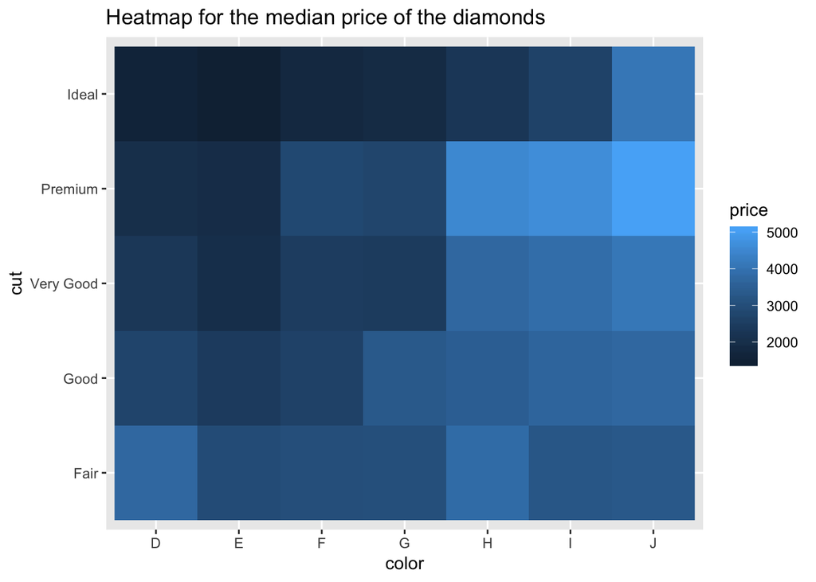

```r
ggplot(diamonds.median, aes(color, cut)) +
  geom_raster(aes(fill = price)) +
  labs(title = "Heatmap for the median price of the diamonds")
```

```r
diamonds.median2 <- aggregate(formula = price ~ color + cut + clarity,
                              data = diamonds, FUN = median)
str(diamonds.median2)
```

```
## 'data.frame':    276 obs. of  4 variables:
##  $ color  : Ord.factor w/ 7 levels "D"<"E"<"F"<"G"<..: 1 2 3 4 5 6 7 1 2 3 ...
##  $ cut    : Ord.factor w/ 5 levels "Fair"<"Good"<..: 1 1 1 1 1 1 1 2 2 2 ...
##  $ clarity: Ord.factor w/ 8 levels "I1"<"SI2"<"SI1"<..: 1 1 1 1 1 1 1 1 1 1 ...
##  $ price  : num  5538 2036 1570 1954 3340 ...
```

Use the data frame `diamonds.median2` to create the below faceted heat maps with `geom_raster`.

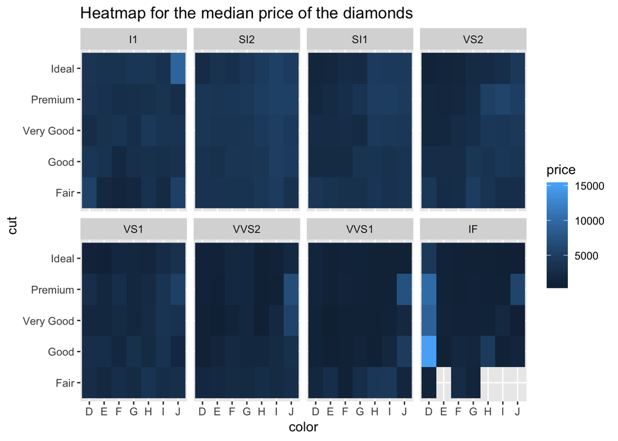

```r
ggplot(diamonds.median2, aes(color, cut)) +
  geom_raster(aes(fill = price)) +
  facet_wrap(~factor(clarity), nrow = 2) +
  labs(title = "Heatmap for the median price of the diamonds")
```

# Part 5

## Density plot

Below is an example of a density plot. Run the ggplot part line by line to see what is happening as each layer is added.

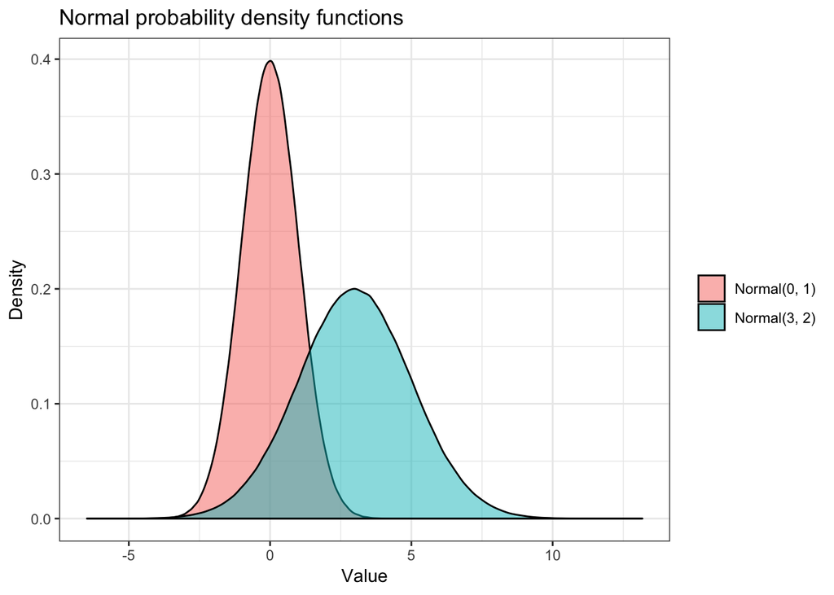

```r
# generate 1000000 random variables from two normal distributions
x <- rnorm(1000000, mean = 0, sd = 1)
y <- rnorm(1000000, mean = 3, sd = 2)

# create a data frame
norm_df <- data.frame(value = c(x, y), norm = rep(c("x", "y"), each = 1000000))

# plot the densities
ggplot(data = norm_df, aes(x = value, fill = norm)) +
  geom_density(alpha = 0.50) +
  labs(x = "Value", y = "Density",
       title = "Normal probability density functions")+
  theme_bw() +
  scale_fill_discrete(name = "",
                      breaks = c("x", "y"),
                      labels = c("Normal(0, 1)", "Normal(3, 2)"))
```